# Supplementary Information 2 - Global annual average landings of Sharks MOU Annex I-listed species reported to FAO (2015-2019)

$~$

$~$

All landings are reported as tonnes of live weight.

The first plot includes the top three nations reporting the highest landings, as can be seen in Figure 3 of the main document. The second plot represents a close up of the landings reported from the remaining nations, as it is seen at the fourth bar within the plots presented in Figure 3 of the main document. Note the scale between the two plots is different.

Colour of nations within plots indicate Sharks MOU and CMS Status: (Dark blue) Sharks MOU Signatory and CMS Party; (light blue) Sharks MOU Signatory only; (green) CMS Party only; (grey) range state. Note that not all colours may be present in any given plot.

$~$

$~$

# By FAO Area (Choose a tab to display)

$~$

$~$

## Area 21 - Atlantic, Northwest

$~$

$~$

Area 21 - Atlantic, Northwest

$~$

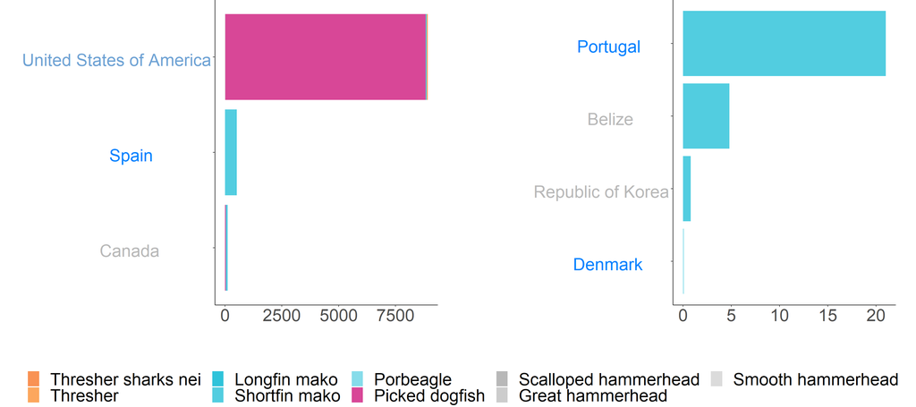

Area 21

| Country | Sharks MOU Status | CMS Status | Great hammerhead | Longfin mako | Picked dogfish | Porbeagle | Scalloped hammerhead | Shortfin mako | Smooth hammerhead | Thresher | Thresher sharks nei | Yearly Average Total |
| --- | --- | --- | --- | --- | --- | --- | --- | --- | --- | --- | --- | --- |
| United States of America | MOU Signatory | Non-Party | 12.20 | - | 8809.20 | - | 3.80 | 49.40 | 0.20 | 36.60 | 3.40 | 8914.80 |
| Spain | MOU Signatory | Party | - | 28.80 | - | - | - | 487.94 | - | - | - | 516.75 |
| Canada | Range State | Non-Party | - | - | 34.40 | 4.60 | - | 79.20 | - | - | - | 118.20 |
| Portugal | MOU Signatory | Party | - | - | - | - | - | 21.00 | - | - | - | 21.00 |
| Belize | Range State | Non-Party | - | - | - | - | - | 4.80 | - | - | - | 4.80 |
| Republic of Korea | Range State | Non-Party | - | - | - | - | - | 0.81 | - | - | - | 0.81 |
| Denmark | MOU Signatory | Party | - | - | - | 0.08 | - | - | - | - | - | 0.08 |

## Area 27 - Atlantic, Northeast

$~$

$~$

Area 27 - Atlantic, Northeast

$~$

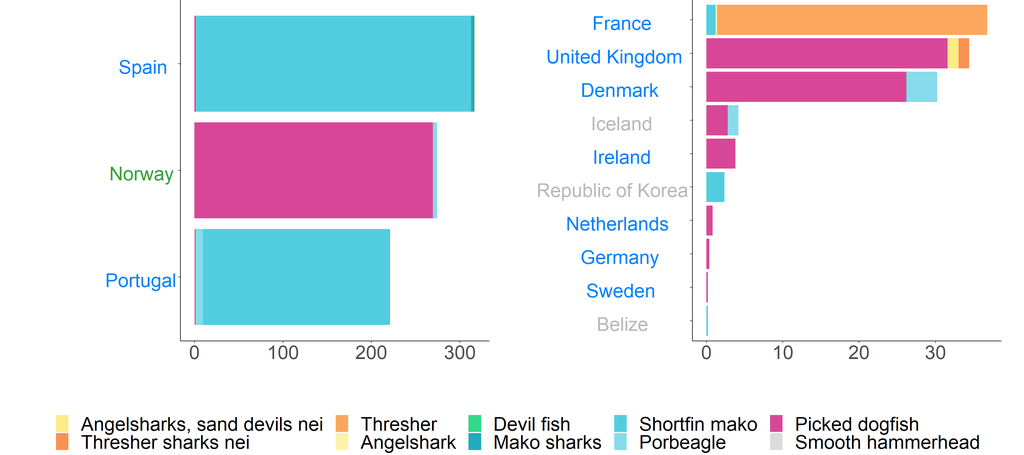

Area 27

| Country | Sharks MOU Status | CMS Status | Angelshark | Angelsharks, sand devils nei | Devil fish | Mako sharks | Picked dogfish | Porbeagle | Shortfin mako | Smooth hammerhead | Thresher | Thresher sharks nei | Yearly Average Total |
| --- | --- | --- | --- | --- | --- | --- | --- | --- | --- | --- | --- | --- | --- |
| Spain | MOU Signatory | Party | 1.09 | - | 0.02 | 3.71 | 1.55 | 0.40 | 310.90 | - | - | - | 317.67 |
| Norway | Range State | Party | - | - | - | - | 269.60 | 4.60 | - | - | - | - | 274.20 |
| Portugal | MOU Signatory | Party | - | - | - | - | 1.00 | 8.60 | 211.40 | 0.20 | 0.20 | - | 221.40 |
| France | MOU Signatory | Party | 0.20 | - | - | - | - | - | 1.20 | - | 35.40 | - | 36.80 |
| United Kingdom | MOU Signatory | Party | - | 1.40 | - | - | 31.60 | - | - | - | - | 1.40 | 34.40 |
| Denmark | MOU Signatory | Party | - | - | - | - | 26.20 | 4.02 | - | - | - | - | 30.22 |
| Iceland | Range State | Non-Party | - | - | - | - | 2.80 | 1.40 | - | - | - | - | 4.20 |
| Ireland | MOU Signatory | Party | - | - | - | - | 3.78 | - | - | - | - | - | 3.78 |
| Republic of Korea | Range State | Non-Party | - | - | - | - | - | - | 2.35 | - | - | - | 2.35 |
| Netherlands | MOU Signatory | Party | - | - | - | - | 0.80 | - | - | - | - | - | 0.80 |
| Germany | MOU Signatory | Party | - | - | - | - | 0.40 | - | - | - | - | - | 0.40 |
| Belize | Range State | Non-Party | - | - | - | - | - | - | 0.20 | - | - | - | 0.20 |
| Sweden | MOU Signatory | Party | - | - | - | - | 0.20 | - | - | - | - | - | 0.20 |

## Area 31 - Atlantic, Western Central

$~$

$~$

Area 31 - Atlantic, Western Central

$~$

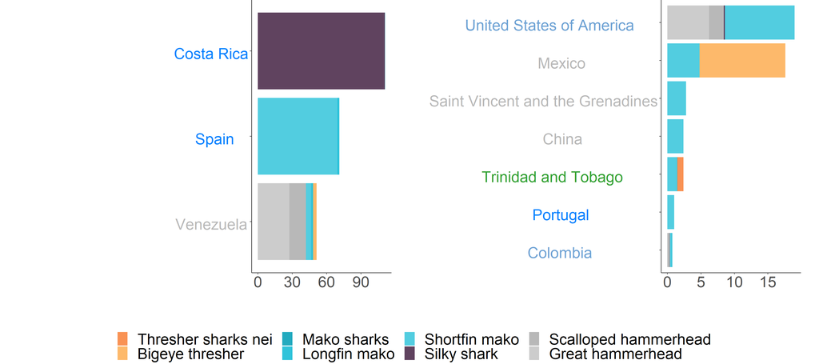

Area 31

| Country | Sharks MOU Status | CMS Status | Bigeye thresher | Great hammerhead | Longfin mako | Mako sharks | Scalloped hammerhead | Shortfin mako | Silky shark | Thresher sharks nei | Yearly Average Total |
| --- | --- | --- | --- | --- | --- | --- | --- | --- | --- | --- | --- |
| Costa Rica | MOU Signatory | Party | - | - | - | - | - | 0.20 | 111.00 | - | 111.20 |
| Spain | MOU Signatory | Party | - | - | 1.79 | - | - | 69.43 | - | - | 71.22 |
| Venezuela | Range State | Non-Party | 3.20 | 27.40 | 1.60 | - | 14.60 | 4.60 | - | - | 51.40 |
| United States of America | MOU Signatory | Non-Party | - | 6.20 | - | - | 2.20 | 10.40 | 0.20 | - | 19.00 |
| Mexico | Range State | Non-Party | 12.80 | - | - | - | - | 4.80 | - | - | 17.60 |
| Saint Vincent and the Grenadines | Range State | Non-Party | - | - | - | - | - | 2.80 | - | - | 2.80 |
| China | Range State | Non-Party | - | - | - | - | - | 2.40 | - | - | 2.40 |
| Trinidad and Tobago | Range State | Party | - | - | - | 0.03 | - | 1.43 | - | 0.93 | 2.39 |
| Portugal | MOU Signatory | Party | - | - | - | - | - | 1.00 | - | - | 1.00 |
| Colombia | MOU Signatory | Non-Party | - | - | 0.09 | - | 0.34 | 0.26 | 0.03 | - | 0.71 |

## Area 34 - Atlantic, Eastern Central

$~$

$~$

Area 34 - Atlantic, Eastern Central

$~$

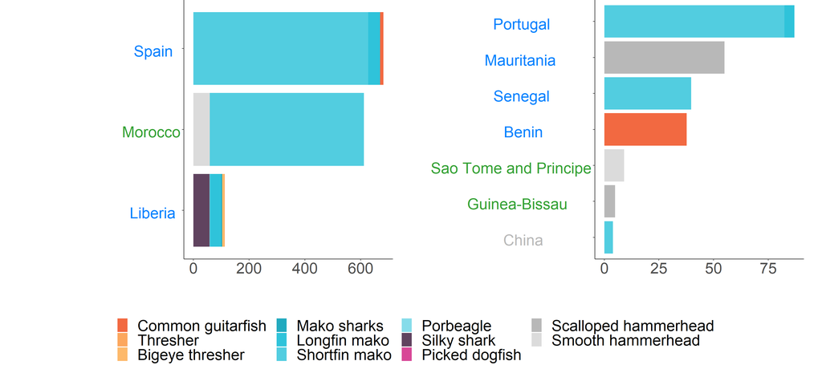

Area 34

| Country | Sharks MOU Status | CMS Status | Bigeye thresher | Common guitarfish | Longfin mako | Mako sharks | Picked dogfish | Porbeagle | Scalloped hammerhead | Shortfin mako | Silky shark | Smooth hammerhead | Thresher | Yearly Average Total |
| --- | --- | --- | --- | --- | --- | --- | --- | --- | --- | --- | --- | --- | --- | --- |
| Spain | MOU Signatory | Party | - | 11.87 | 42.60 | - | 0.24 | - | - | 627.01 | - | - | - | 681.71 |
| Morocco | Range State | Party | - | - | - | - | - | - | - | 551.94 | - | 59.60 | - | 611.54 |
| Liberia | MOU Signatory | Party | 7.60 | - | 39.80 | 4.00 | - | 1.40 | - | - | 58.80 | - | 1.00 | 112.60 |
| Portugal | MOU Signatory | Party | - | - | 4.60 | - | - | - | - | 82.40 | - | - | - | 87.00 |
| Mauritania | MOU Signatory | Party | - | - | - | - | - | - | 55.00 | - | - | - | - | 55.00 |
| Senegal | MOU Signatory | Party | - | - | - | - | - | - | - | 39.80 | - | - | - | 39.80 |
| Benin | MOU Signatory | Party | - | 37.70 | - | - | - | - | - | - | - | - | - | 37.70 |
| Sao Tome and Principe | Range State | Party | - | - | - | - | - | - | - | - | - | 9.11 | - | 9.11 |
| Guinea-Bissau | Range State | Party | - | - | - | - | - | - | 5.00 | - | - | - | - | 5.00 |
| China | Range State | Non-Party | - | - | - | - | - | - | - | 4.00 | - | - | - | 4.00 |

## Area 37 - Mediterranean and Black Sea

$~$

$~$

Area 37 - Mediterranean and Black Sea

$~$

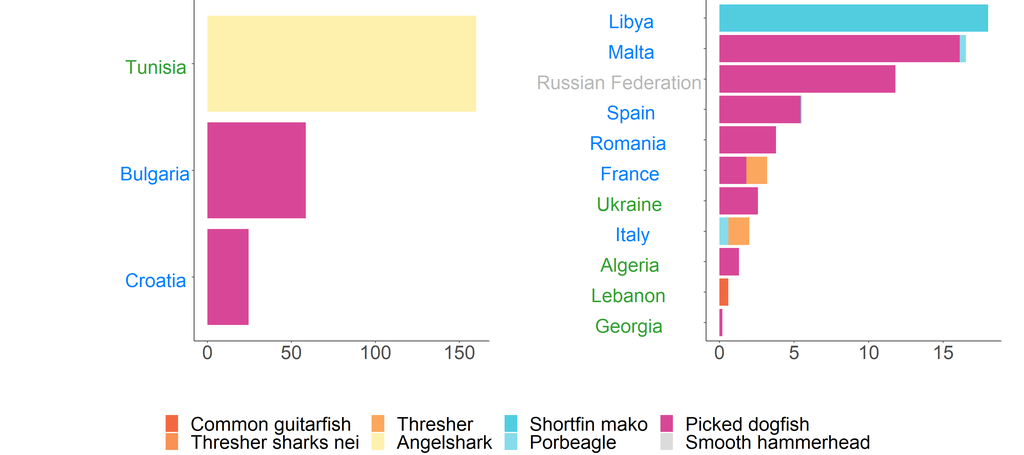

Area 37

| Country | Sharks MOU Status | CMS Status | Angelshark | Common guitarfish | Picked dogfish | Porbeagle | Shortfin mako | Smooth hammerhead | Thresher | Thresher sharks nei | Yearly Average Total |
| --- | --- | --- | --- | --- | --- | --- | --- | --- | --- | --- | --- |
| Tunisia | Range State | Party | 160.00 | - | - | - | - | - | - | - | 160.00 |
| Bulgaria | MOU Signatory | Party | - | - | 58.60 | - | - | - | - | - | 58.60 |
| Croatia | MOU Signatory | Party | - | - | 24.60 | - | - | - | - | - | 24.60 |
| Libya | MOU Signatory | Party | - | - | - | - | 18.00 | - | - | - | 18.00 |
| Malta | MOU Signatory | Party | - | - | 16.11 | 0.40 | - | - | - | - | 16.51 |
| Russian Federation | Range State | Non-Party | - | - | 11.80 | - | - | - | - | - | 11.80 |
| Spain | MOU Signatory | Party | - | - | 5.43 | 0.01 | 0.04 | 0.01 | - | - | 5.49 |
| Romania | MOU Signatory | Party | - | - | 3.80 | - | - | - | - | - | 3.80 |
| France | MOU Signatory | Party | - | - | 1.80 | - | - | - | 1.40 | - | 3.20 |
| Ukraine | Range State | Party | - | - | 2.59 | - | - | - | - | - | 2.59 |
| Italy | MOU Signatory | Party | - | - | - | 0.60 | - | - | 1.40 | - | 2.00 |
| Algeria | Range State | Party | - | - | 1.32 | - | - | - | - | - | 1.32 |
| Lebanon | Range State | Party | - | 0.60 | - | - | - | - | - | - | 0.60 |
| Georgia | Range State | Party | - | - | 0.20 | - | - | - | - | - | 0.20 |

## Area 41 - Atlantic, Southwest

$~$

$~$

Area 41 - Atlantic, Southwest

$~$

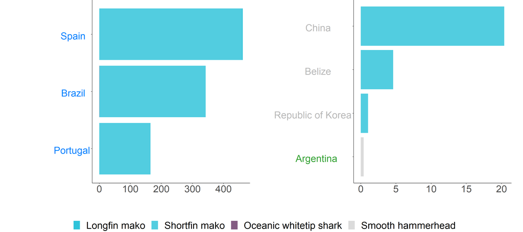

Area 41

| Country | Sharks MOU Status | CMS Status | Longfin mako | Oceanic whitetip shark | Shortfin mako | Smooth hammerhead | Yearly Average Total |
| --- | --- | --- | --- | --- | --- | --- | --- |
| Spain | MOU Signatory | Party | 2.44 | - | 459.71 | - | 462.15 |
| Brazil | MOU Signatory | Party | - | 0.60 | 342.00 | - | 342.60 |
| Portugal | MOU Signatory | Party | 1.20 | - | 163.60 | - | 164.80 |
| China | Range State | Non-Party | - | - | 20.40 | - | 20.40 |
| Belize | Range State | Non-Party | - | - | 4.60 | - | 4.60 |
| Republic of Korea | Range State | Non-Party | - | - | 1.02 | - | 1.02 |
| Argentina | Range State | Party | - | - | - | 0.40 | 0.40 |

## Area 47 - Atlantic, Southeast

$~$

$~$

Area 47 - Atlantic, Southeast

$~$

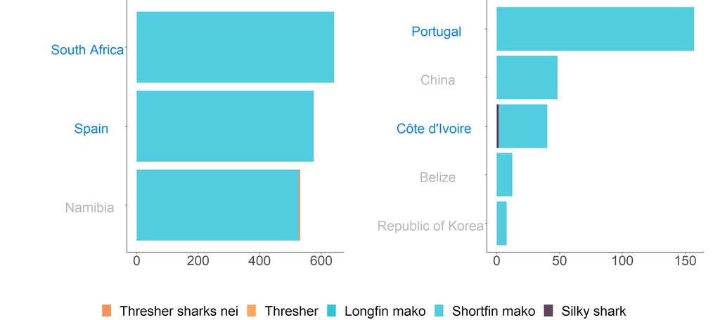

Area 47

| Country | Sharks MOU Status | CMS Status | Longfin mako | Shortfin mako | Silky shark | Thresher | Thresher sharks nei | Yearly Average Total |
| --- | --- | --- | --- | --- | --- | --- | --- | --- |
| South Africa | MOU Signatory | Party | - | 641.96 | - | 0.60 | - | 642.56 |
| Spain | MOU Signatory | Party | 0.04 | 576.04 | - | - | - | 576.08 |
| Namibia | Range State | Non-Party | - | 526.80 | - | - | 4.80 | 531.60 |
| Portugal | MOU Signatory | Party | - | 157.20 | - | - | - | 157.20 |
| China | Range State | Non-Party | - | 48.40 | - | - | - | 48.40 |
| Côte d’Ivoire | MOU Signatory | Party | - | 38.60 | 1.60 | - | - | 40.20 |
| Belize | Range State | Non-Party | - | 12.40 | - | - | - | 12.40 |
| Republic of Korea | Range State | Non-Party | - | 7.96 | - | - | - | 7.96 |

## Area 51 - Indian Ocean, Western

$~$

$~$

Area 51 - Indian Ocean, Western

$~$

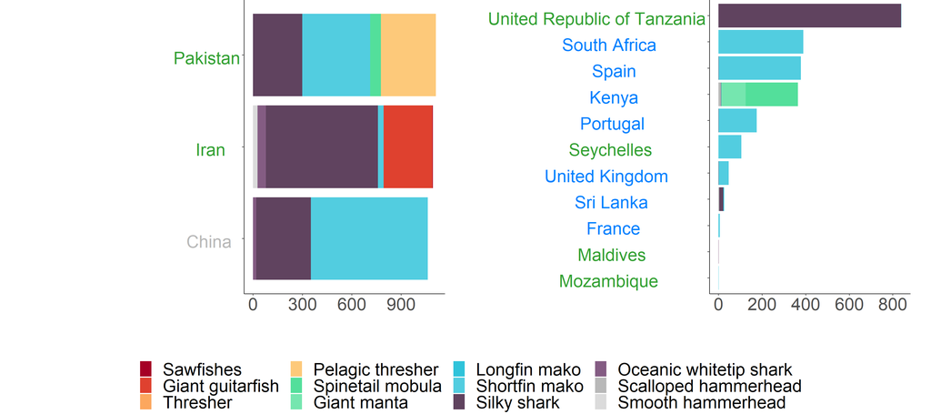

Area 51

| Country | Sharks MOU Status | CMS Status | Giant guitarfish | Giant manta | Longfin mako | Oceanic whitetip shark | Pelagic thresher | Sawfishes | Scalloped hammerhead | Shortfin mako | Silky shark | Smooth hammerhead | Spinetail mobula | Thresher | Yearly Average Total |
| --- | --- | --- | --- | --- | --- | --- | --- | --- | --- | --- | --- | --- | --- | --- | --- |
| Pakistan | Range State | Party | - | - | - | - | 334.60 | - | - | 413.80 | 298.20 | - | 64.00 | - | 1110.60 |
| Iran | Range State | Party | 297.20 | - | - | 51.20 | - | 2.60 | - | 33.60 | 680.40 | 27.20 | - | - | 1092.20 |
| China | Range State | Non-Party | - | - | - | 18.80 | - | - | - | 709.60 | 333.00 | - | - | - | 1061.40 |
| United Republic of Tanzania | Range State | Party | - | - | - | - | - | - | - | 1.40 | 837.80 | - | - | - | 839.20 |
| South Africa | MOU Signatory | Party | - | - | - | - | - | - | - | 389.00 | - | - | - | - | 389.00 |
| Spain | MOU Signatory | Party | - | - | 0.12 | - | - | - | - | 377.65 | 0.18 | - | - | - | 377.95 |
| Kenya | MOU Signatory | Party | - | 111.00 | - | - | - | - | 10.60 | 1.60 | 0.60 | - | 240.00 | - | 363.80 |
| Portugal | MOU Signatory | Party | - | - | - | - | - | - | - | 175.20 | 0.20 | - | - | - | 175.40 |
| Seychelles | Range State | Party | - | - | - | - | - | - | - | 104.00 | - | - | - | - | 104.00 |
| United Kingdom | MOU Signatory | Party | - | - | - | - | - | - | - | 45.80 | 0.40 | - | - | - | 46.20 |
| Sri Lanka | MOU Signatory | Party | - | - | 3.50 | - | - | - | 2.66 | - | 18.92 | - | - | - | 25.08 |
| France | MOU Signatory | Party | - | - | - | - | - | - | - | 5.40 | - | - | - | - | 5.40 |
| Maldives | Range State | Party | - | - | - | 0.80 | - | - | - | - | - | - | - | 0.20 | 1.00 |
| Mozambique | Range State | Party | - | - | - | - | - | - | - | 0.40 | - | - | - | - | 0.40 |

## Area 57 - Indian Ocean, Eastern

$~$

$~$

Area 57 - Indian Ocean, Eastern

$~$

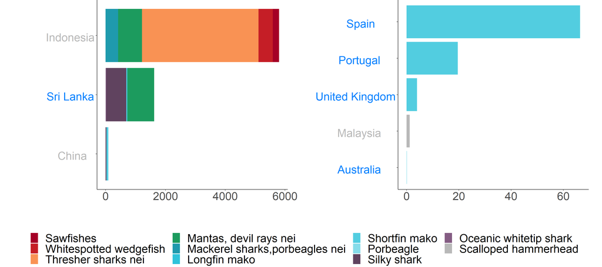

Area 57

| Country | Sharks MOU Status | CMS Status | Longfin mako | Mackerel sharks,porbeagles nei | Mantas, devil rays nei | Oceanic whitetip shark | Porbeagle | Sawfishes | Scalloped hammerhead | Shortfin mako | Silky shark | Thresher sharks nei | Whitespotted wedgefish | Yearly Average Total |
| --- | --- | --- | --- | --- | --- | --- | --- | --- | --- | --- | --- | --- | --- | --- |
| Indonesia | Range State | Non-Party | - | 415.80 | 803.00 | - | - | 208.80 | - | - | - | 3894.40 | 481.40 | 5803.40 |
| Sri Lanka | MOU Signatory | Party | 1.78 | - | 901.10 | 17.80 | - | - | 2.26 | 30.52 | 672.86 | - | - | 1626.32 |
| China | Range State | Non-Party | - | - | - | 0.80 | - | - | - | 60.40 | 27.80 | - | - | 89.00 |
| Spain | MOU Signatory | Party | - | - | - | - | - | - | - | 66.40 | - | - | - | 66.40 |
| Portugal | MOU Signatory | Party | - | - | - | - | - | - | - | 19.60 | - | - | - | 19.60 |
| United Kingdom | MOU Signatory | Party | - | - | - | - | - | - | - | 4.00 | - | - | - | 4.00 |
| Malaysia | Range State | Non-Party | - | - | - | - | - | - | 1.20 | - | - | - | - | 1.20 |
| Australia | MOU Signatory | Party | - | - | - | - | 0.10 | - | - | - | - | - | - | 0.10 |

## Area 61 - Pacific, Northwest

$~$

$~$

Area 61 - Pacific, Northwest

$~$

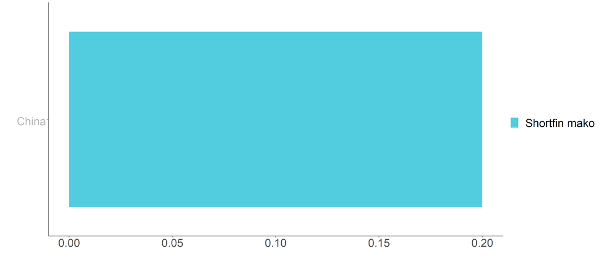

Area 61

| Country | Sharks MOU Status | CMS Status | Shortfin mako | Yearly Average Total |
| --- | --- | --- | --- | --- |
| China | Range State | Non-Party | 0.20 | 0.20 |

## Area 67 - Pacific, Northeast

$~$

$~$

Area 67 - Pacific, Northeast

$~$

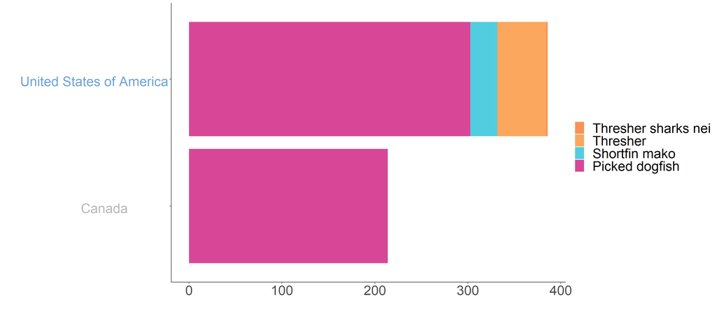

Area 67

| Country | Sharks MOU Status | CMS Status | Picked dogfish | Shortfin mako | Thresher | Thresher sharks nei | Yearly Average Total |
| --- | --- | --- | --- | --- | --- | --- | --- |
| United States of America | MOU Signatory | Non-Party | 302.80 | 29.00 | 52.60 | 1.60 | 386.00 |
| Canada | Range State | Non-Party | 213.80 | - | - | - | 213.80 |

## Area 71 - Pacific, Western Central

$~$

$~$

Area 71 - Pacific, Western Central

$~$

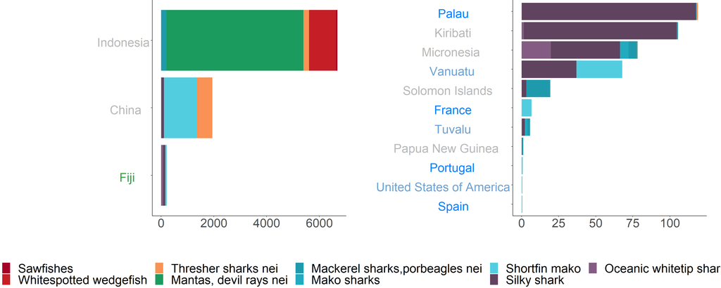

Area 71

| Country | Sharks MOU Status | CMS Status | Mackerel sharks,porbeagles nei | Mako sharks | Mantas, devil rays nei | Oceanic whitetip shark | Sawfishes | Shortfin mako | Silky shark | Thresher sharks nei | Whitespotted wedgefish | Yearly Average Total |
| --- | --- | --- | --- | --- | --- | --- | --- | --- | --- | --- | --- | --- |
| Indonesia | Range State | Non-Party | 200.40 | - | 5196.40 | - | 48.00 | - | - | 217.52 | 1023.54 | 6685.86 |
| China | Range State | Non-Party | - | - | - | 14.40 | - | 1240.80 | 97.80 | 591.80 | - | 1944.80 |
| Fiji | Range State | Party | - | - | - | 83.00 | - | 58.60 | 74.80 | 1.00 | - | 217.40 |
| Palau | MOU Signatory | Party | - | 0.40 | - | 0.34 | - | - | 117.22 | 0.86 | - | 118.82 |
| Kiribati | Range State | Non-Party | 0.80 | - | - | 1.60 | - | - | 103.00 | - | - | 105.40 |
| Micronesia | Range State | Non-Party | 5.60 | 5.80 | - | 19.80 | - | - | 46.60 | 0.60 | - | 78.40 |
| Vanuatu | MOU Signatory | Non-Party | - | - | - | - | - | 30.80 | 37.00 | - | - | 67.80 |
| Solomon Islands | Range State | Non-Party | 16.00 | - | - | 0.20 | - | - | 3.00 | 0.40 | - | 19.60 |
| France | MOU Signatory | Party | - | - | - | - | - | 6.80 | - | - | - | 6.80 |
| Tuvalu | MOU Signatory | Non-Party | 1.80 | 1.80 | - | 0.40 | - | - | 1.80 | - | - | 5.80 |
| Papua New Guinea | Range State | Non-Party | 1.00 | - | - | 0.20 | - | - | - | - | - | 1.20 |
| Portugal | MOU Signatory | Party | - | - | - | - | - | 0.80 | - | - | - | 0.80 |
| Spain | MOU Signatory | Party | - | - | - | - | - | 0.60 | - | - | - | 0.60 |
| United States of America | MOU Signatory | Non-Party | - | - | - | - | - | 0.60 | - | - | - | 0.60 |

## Area 77 - Pacific, Eastern Central

$~$

$~$

Area 77 - Pacific, Eastern Central

$~$

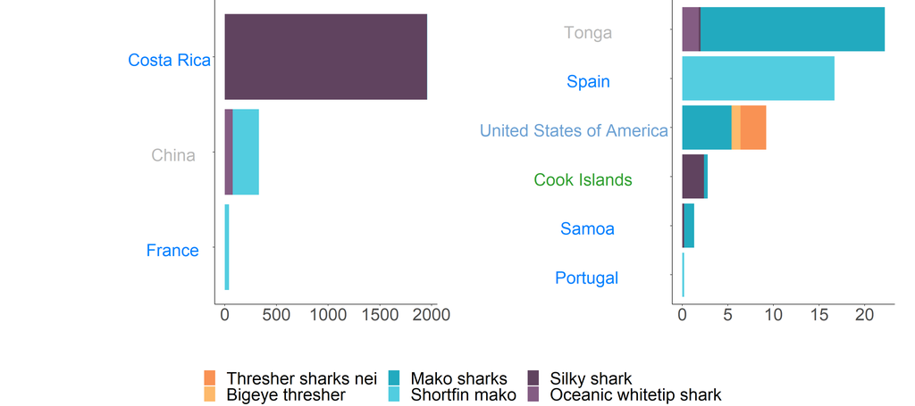

Area 77

| Country | Sharks MOU Status | CMS Status | Bigeye thresher | Mako sharks | Oceanic whitetip shark | Shortfin mako | Silky shark | Thresher sharks nei | Yearly Average Total |
| --- | --- | --- | --- | --- | --- | --- | --- | --- | --- |
| Costa Rica | MOU Signatory | Party | - | - | - | 0.60 | 1957.60 | - | 1958.20 |
| China | Range State | Non-Party | - | - | 77.80 | 253.40 | - | - | 331.20 |
| France | MOU Signatory | Party | - | - | - | 40.40 | - | - | 40.40 |
| Tonga | Range State | Non-Party | - | 20.20 | 1.80 | - | 0.20 | - | 22.20 |
| Spain | MOU Signatory | Party | - | - | - | 16.70 | - | - | 16.70 |
| United States of America | MOU Signatory | Non-Party | 1.00 | 5.40 | - | - | - | 2.80 | 9.20 |
| Cook Islands | Range State | Party | - | 0.40 | - | - | 2.40 | - | 2.80 |
| Samoa | MOU Signatory | Party | - | 1.10 | - | - | 0.20 | - | 1.30 |
| Portugal | MOU Signatory | Party | - | - | - | 0.20 | - | - | 0.20 |

## Area 81 - Pacific, Southwest

$~$

$~$

Area 81 - Pacific, Southwest

$~$

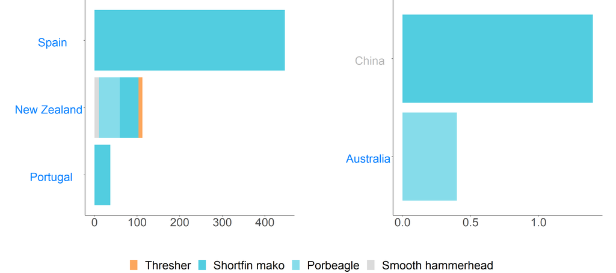

Area 81

| Country | Sharks MOU Status | CMS Status | Porbeagle | Shortfin mako | Smooth hammerhead | Thresher | Yearly Average Total |
| --- | --- | --- | --- | --- | --- | --- | --- |
| Spain | MOU Signatory | Party | - | 447.08 | - | - | 447.08 |
| New Zealand | MOU Signatory | Party | 49.00 | 43.80 | 10.60 | 9.00 | 112.40 |
| Portugal | MOU Signatory | Party | - | 37.20 | - | - | 37.20 |
| China | Range State | Non-Party | - | 1.40 | - | - | 1.40 |
| Australia | MOU Signatory | Party | 0.40 | - | - | - | 0.40 |

## Area 87 - Pacific, Southeast

$~$

$~$

Area 87 - Pacific, Southeast

$~$

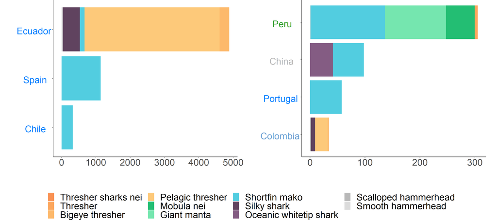

Area 87

| Country | Sharks MOU Status | CMS Status | Bigeye thresher | Giant manta | Mobula nei | Oceanic whitetip shark | Pelagic thresher | Scalloped hammerhead | Shortfin mako | Silky shark | Smooth hammerhead | Thresher | Thresher sharks nei | Yearly Average Total |
| --- | --- | --- | --- | --- | --- | --- | --- | --- | --- | --- | --- | --- | --- | --- |
| Ecuador | MOU Signatory | Party | 279.02 | - | - | 4.00 | 3934.27 | 3.80 | 138.18 | 497.01 | 29.26 | - | 0.20 | 4885.74 |
| Spain | MOU Signatory | Party | - | - | - | - | - | - | 1139.81 | - | - | - | - | 1139.81 |
| Chile | MOU Signatory | Party | - | - | - | - | - | - | 328.00 | - | - | - | - | 328.00 |
| Peru | Range State | Party | - | 111.00 | 52.38 | - | - | - | 135.40 | - | 0.84 | 5.40 | - | 305.02 |
| China | Range State | Non-Party | - | - | - | 41.60 | - | - | 56.40 | - | - | - | - | 98.00 |
| Portugal | MOU Signatory | Party | - | - | - | - | - | - | 57.60 | - | - | - | - | 57.60 |
| Colombia | MOU Signatory | Non-Party | 2.40 | - | - | - | 22.68 | 1.60 | - | 7.68 | - | - | - | 34.36 |

## Area SO - Antartic

$~$

$~$

Area SO - Antartic

$~$

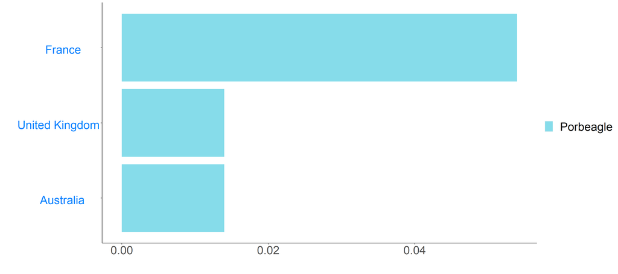

Area SO

| Country | Sharks MOU Status | CMS Status | Porbeagle | Yearly Average Total |
| --- | --- | --- | --- | --- |
| France | MOU Signatory | Party | 0.05 | 0.05 |
| Australia | MOU Signatory | Party | 0.01 | 0.01 |
| United Kingdom | MOU Signatory | Party | 0.01 | 0.01 |